# Homework 06

## Question 1: Compare KNN and logistic regression

Use breast-cancer.csv, which contains 569 cases from the [Wisconsin Diagnostic Breast Cancer dataset](https://archive.ics.uci.edu/dataset/17/breast%2Bcancer%2Bwisconsin%2Bdiagnostic). Predict `y` (1 for malignant and 0 for benign) using `mean_radius`, `mean_texture`, and `mean_smoothness`.

Set a random seed and randomly split the observations into 70% training and 30% test data. Use the same split for every model. Standardize the predictors using the training means and standard deviations, and apply the same transformations to the test data.

Fit ordinary logistic regression with an intercept and no penalty, and KNN with Euclidean distance, equal neighbor weights, and

$$k\in\{5,15,25,35,45\}.$$

Using the estimated probabilities for `y = 1` on the test data, plot all six ROC curves in one figure and report their AUC values. Which of the six fitted models do you prefer? Give a brief justification based on your results.

```r
library(tidyverse)
library(kknn)

cancer <- read_csv("data/breast-cancer.csv")
str(cancer)
```

```
spc_tbl_ [569 × 4] (S3: spec_tbl_df/tbl_df/tbl/data.frame)
 $ mean_radius    : num [1:569] 18 20.6 19.7 11.4 20.3 ...
 $ mean_texture   : num [1:569] 10.4 17.8 21.2 20.4 14.3 ...
 $ mean_smoothness: num [1:569] 0.1184 0.0847 0.1096 0.1425 0.1003 ...
 $ y              : num [1:569] 1 1 1 1 1 1 1 1 1 1 ...
 - attr(*, "spec")=
  .. cols(
  ..   mean_radius = col_double(),
  ..   mean_texture = col_double(),
  ..   mean_smoothness = col_double(),
  ..   y = col_double()
  .. )
 - attr(*, "problems")=<pointer: 0x12d7fa020>
```

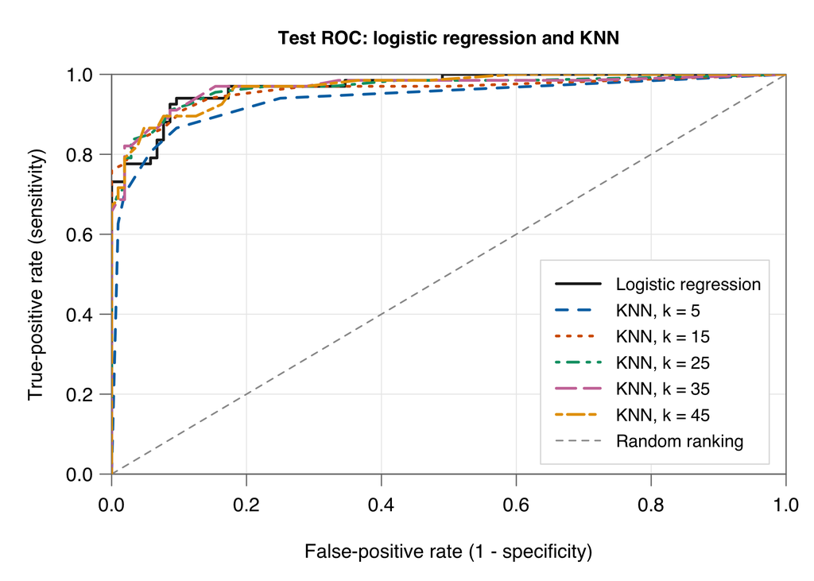

```r
set.seed(1324)

k_val <- c(5, 15, 25, 35, 45)

train_index <- sample(seq_len(nrow(cancer)), size = floor(0.7 * nrow(cancer)))

train <- cancer[train_index, ]
test <- cancer[-train_index, ]

train_sd <- sapply(train[c("mean_radius", "mean_texture", "mean_smoothness")], sd)

X_bar <- colMeans(train[c("mean_radius", "mean_texture", "mean_smoothness")])

train_scaled <- train
test_scaled <- test

train_scaled$mean_radius <- (train$mean_radius - X_bar["mean_radius"]) / train_sd["mean_radius"]
train_scaled$mean_texture <- (train$mean_texture - X_bar["mean_texture"]) / train_sd["mean_texture"]
train_scaled$mean_smoothness <- (train$mean_smoothness - X_bar["mean_smoothness"]) / train_sd["mean_smoothness"]

test_scaled$mean_radius <- (test$mean_radius - X_bar["mean_radius"]) / train_sd["mean_radius"]
test_scaled$mean_texture <- (test$mean_texture - X_bar["mean_texture"]) / train_sd["mean_texture"]
test_scaled$mean_smoothness <- (test$mean_smoothness - X_bar["mean_smoothness"]) / train_sd["mean_smoothness"]

fit <- glm(y ~ ., data = train_scaled, family = binomial())

logistic_prob <- predict(fit, newdata = test_scaled, type = "response")

knn_probs <- vector("list", length(k_val))
names(knn_probs) <- paste0("k_", k_val)

for (i in seq_along(k_val)) {
  knn_fit <- kknn(y ~ ., train = train_scaled, test = test_scaled,
  k = k_val[i], distance = 2, kernel = "rectangular", scale = FALSE)

  knn_probs[[i]] <- knn_fit$fitted.values
}

cutoffs <- c(Inf, sort(unique(logistic_prob), decreasing = TRUE), -Inf)

TPR <- numeric(length(cutoffs))
FPR <- numeric(length(cutoffs))

for (j in seq_along(cutoffs)) {
  predicted <- as.integer(logistic_prob >= cutoffs[j])

  TPR[j] <- sum(predicted == 1 & test_scaled$y == 1) /
            sum(test_scaled$y == 1)

  FPR[j] <- sum(predicted == 1 & test_scaled$y == 0) /
            sum(test_scaled$y == 0)
}

# Save graphics settings and restore them after the figure.
old_par <- par(no.readonly = TRUE)
par(mar = c(4.6, 4.8, 3.2, 1.2), mgp = c(2.8, 0.8, 0),
    las = 1, family = "sans", cex = 1, bg = "white")

knn_colors <- c("#0072B2", "#D55E00", "#009E73", "#CC79A7", "#E69F00")
knn_lty <- c(2, 3, 4, 5, 6)

plot(
  FPR, TPR, type = "n",
  xlim = c(0, 1), ylim = c(0, 1), xaxs = "i", yaxs = "i",
  axes = FALSE,
  xlab = "False-positive rate (1 - specificity)",
  ylab = "True-positive rate (sensitivity)",
  main = "Test ROC: logistic regression and KNN",
  cex.main = 0.95
)
axis_ticks <- seq(0, 1, by = 0.2)
abline(h = axis_ticks, v = axis_ticks, col = "#EAEAEA", lwd = 0.8)
axis(1, at = axis_ticks, labels = sprintf("%.1f", axis_ticks), col = "#777777")
axis(2, at = axis_ticks, labels = sprintf("%.1f", axis_ticks), col = "#777777")
box(col = "#777777")
abline(a = 0, b = 1, lty = 2, col = "#999999", lwd = 1.3)
lines(FPR, TPR, col = "#222222", lwd = 2.3)

knn_rocs <- vector("list", length(k_val))

for (i in seq_along(k_val)) {
  probs <- knn_probs[[i]]

  cutoffs_knn <- c(Inf, sort(unique(probs), decreasing = TRUE), -Inf)
  TPR_knn <- numeric(length(cutoffs_knn))
  FPR_knn <- numeric(length(cutoffs_knn))

  for (j in seq_along(cutoffs_knn)) {
    predicted <- as.integer(probs >= cutoffs_knn[j])

    TPR_knn[j] <- sum(predicted == 1 & test_scaled$y == 1) /
                  sum(test_scaled$y == 1)

    FPR_knn[j] <- sum(predicted == 1 & test_scaled$y == 0) /
                  sum(test_scaled$y == 0)
  }

  knn_rocs[[i]] <- data.frame(FPR = FPR_knn, TPR = TPR_knn)

  lines(FPR_knn, TPR_knn, col = knn_colors[i], lty = knn_lty[i], lwd = 2.3)
}

legend(
  "bottomright", inset = 0.025,
  legend = c("Logistic regression", paste("KNN, k =", k_val), "Random ranking"),
  col = c("#222222", knn_colors, "#999999"),
  lty = c(1, knn_lty, 2),
  lwd = c(rep(2.3, 6), 1.3),
  cex = 0.9, y.intersp = 1.25, seg.len = 2.8,
  bty = "o", bg = "white", box.col = "#DDDDDD"
)
```

```r
par(old_par)

logistic_auc <- sum(diff(FPR) * (head(TPR, -1) + tail(TPR, -1)) / 2)

knn_auc <- numeric(length(k_val))
for (i in seq_along(k_val)) {
  roc <- knn_rocs[[i]]
  knn_auc[i] <- sum(
    diff(roc$FPR) * (head(roc$TPR, -1) + tail(roc$TPR, -1)) / 2
  )
}

auc_results <- data.frame(
  Model = c("Logistic regression", paste("KNN, k =", k_val)),
  AUC = c(logistic_auc, knn_auc)
)

knitr::kable(auc_results, digits = 4, caption = "Test AUC for all six models")
```

Test AUC for all six models

| Model | AUC |
| --- | --- |
| Logistic regression | 0.9689 |
| KNN, k = 5 | 0.9371 |
| KNN, k = 15 | 0.9598 |
| KNN, k = 25 | 0.9657 |
| KNN, k = 35 | 0.9669 |
| KNN, k = 45 | 0.9684 |

For this split, I will choose the logistic regression over the KNN fits. The AUC of the logistic regression is 0.9689, which is the highest AUC among all fits. The AUC for KNN k=45 is pretty close to the one of logistic regression. The higher AUC indicates that logistic regression is slightly better at ranking malignant cases above benign cases on this test set. However, KNN with $k=45$ has an AUC of 0.9684, only about 0.0005 lower, so their performance is very similar. This result supports my preference for logistic regression on this split, but does not show that it will always outperform KNN.

## Question 2: Training and test ROC curves

Use the same data, training/test split, and standardization as in Question 1. Fit KNN with Euclidean distance, equal neighbor weights, and

$$k\in\{1,3,5,10,20\}.$$

Use each fitted model to estimate probabilities for both the training and test observations. For training predictions, include each observation itself among its $k$ nearest neighbors.

For each $k$, use a separate panel to show the training and test ROC curves together. Report both AUC values.

Explain the difference between training and test performance and how it changes with $k$. In particular, explain what happens at $k=1$ and why training performance may not reflect performance on new observations.

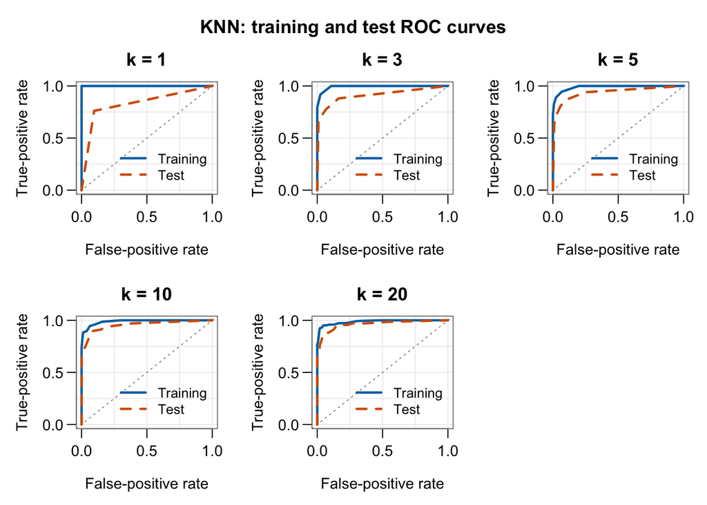

```r
#| fig-width: 9
#| fig-height: 6
#| fig-dpi: 150

k_val_q2 <- c(1, 3, 5, 10, 20)

knn_probs2 <- vector("list", length(k_val_q2))
names(knn_probs2) <- paste0("k_", k_val_q2)

knn_train_probs2 <- vector("list", length(k_val_q2))
names(knn_train_probs2) <- paste0("k_", k_val_q2)

train_rocs2 <- vector("list", length(k_val_q2))
test_rocs2 <- vector("list", length(k_val_q2))

for (i in seq_along(k_val_q2)) {
  knn_fit2 <- kknn(y ~ ., train = train_scaled, test = test_scaled,
  k = k_val_q2[i], distance = 2, kernel = "rectangular", scale = FALSE)

  knn_probs2[[i]] <- knn_fit2$fitted.values

  knn_train_fit2 <- kknn(y ~ ., train = train_scaled, test = train_scaled,
  k = k_val_q2[i], distance = 2, kernel = "rectangular", scale = FALSE)

  knn_train_probs2[[i]] <- knn_train_fit2$fitted.values

  train_probs <- knn_train_probs2[[i]]
  test_probs <- knn_probs2[[i]]

  train_cutoffs <- c(Inf, sort(unique(train_probs), decreasing = TRUE), -Inf)

  test_cutoffs <- c(Inf, sort(unique(test_probs), decreasing = TRUE), -Inf)

  TPR_train <- numeric(length(train_cutoffs))
  FPR_train <- numeric(length(train_cutoffs))

  for (j in seq_along(train_cutoffs)) {
    predicted_train <- as.integer(train_probs >= train_cutoffs[j])

    TPR_train[j] <- sum(predicted_train == 1 & train_scaled$y == 1) / sum(train_scaled$y == 1)

    FPR_train[j] <- sum(predicted_train == 1 & train_scaled$y == 0) / sum(train_scaled$y == 0)
  }

  TPR_test <- numeric(length(test_cutoffs))
  FPR_test <- numeric(length(test_cutoffs))

  for (j in seq_along(test_cutoffs)) {
    predicted_test <- as.integer(test_probs >= test_cutoffs[j])

    TPR_test[j] <- sum(predicted_test == 1 & test_scaled$y == 1) / sum(test_scaled$y == 1)

    FPR_test[j] <- sum(predicted_test == 1 & test_scaled$y == 0) / sum(test_scaled$y == 0)
  }

  train_rocs2[[i]] <- data.frame(FPR = FPR_train, TPR = TPR_train)
  test_rocs2[[i]] <- data.frame(FPR = FPR_test, TPR = TPR_test)
}


old_par <- par(no.readonly = TRUE)
par(
  mfrow = c(2, 3),
  mar = c(4.2, 4.2, 2.5, 1),
  oma = c(0, 0, 2, 0),
  mgp = c(2.5, 0.7, 0),
  cex = 0.9, las = 1, bg = "white"
)

for (i in seq_along(k_val_q2)) {
  plot(
    train_rocs2[[i]]$FPR, train_rocs2[[i]]$TPR,
    type = "n", xlim = c(0, 1), ylim = c(0, 1),
    axes = FALSE,
    xlab = "False-positive rate",
    ylab = "True-positive rate",
    main = paste("k =", k_val_q2[i])
  )

  ticks <- seq(0, 1, by = 0.25)
  abline(h = ticks, v = ticks, col = "#EEEEEE")
  axis(1, at = c(0, 0.5, 1))
  axis(2, at = c(0, 0.5, 1))
  box(col = "#888888")
  abline(a = 0, b = 1, col = "#999999", lty = 3)

  lines(
    train_rocs2[[i]]$FPR, train_rocs2[[i]]$TPR,
    col = "#0072B2", lwd = 2.3, lty = 1
  )
  lines(
    test_rocs2[[i]]$FPR, test_rocs2[[i]]$TPR,
    col = "#D55E00", lwd = 2.3, lty = 2
  )

  legend(
    "bottomright", inset = 0.03,
    legend = c("Training", "Test"),
    col = c("#0072B2", "#D55E00"),
    lty = c(1, 2), lwd = 2.3,
    bty = "n", cex = 0.9
  )
}

plot.new()  # Leave the sixth panel empty
mtext(
  "KNN: training and test ROC curves",
  outer = TRUE, font = 2, cex = 1.1
)
```

```r
par(old_par)

train_auc2 <- numeric(length(k_val_q2))
test_auc2 <- numeric(length(k_val_q2))

for (i in seq_along(k_val_q2)) {
  train_roc <- train_rocs2[[i]]
  test_roc <- test_rocs2[[i]]

  train_auc2[i] <- sum(
    diff(train_roc$FPR) *
      (head(train_roc$TPR, -1) + tail(train_roc$TPR, -1)) / 2
  )

  test_auc2[i] <- sum(
    diff(test_roc$FPR) *
      (head(test_roc$TPR, -1) + tail(test_roc$TPR, -1)) / 2
  )
}

auc_results2 <- data.frame(
  k = k_val_q2,
  Training_AUC = train_auc2,
  Test_AUC = test_auc2
)

knitr::kable(
  auc_results2,
  digits = 4,
  col.names = c("k", "Training AUC", "Test AUC"),
  caption = "KNN training and test AUC"
)
```

KNN training and test AUC

| k | Training AUC | Test AUC |
| --- | --- | --- |
| 1 | 1.0000 | 0.8325 |
| 3 | 0.9931 | 0.9112 |
| 5 | 0.9888 | 0.9371 |
| 10 | 0.9885 | 0.9547 |
| 20 | 0.9865 | 0.9627 |

For each $k$, the training split’s AUC is larger than the testing split. When $k=1$, the training split’s AUC was 1.0, while the testing split’s was 0.8325. That is a decent amount of difference between the two AUC. However, as $k$ increases, the difference between the two AUC decreases. The two values’ gap narrows over the $k$ values considered.

At $k=1$, each training observation is its own nearest neighbor, so the model uses that observation’s outcome to predict itself. This explains the perfect training AUC. Test observations don’t have that advantage because their predictions come from the training data, which is why perfect training performance doesn’t necessarily mean good performance on new cases. As $k$ increases, the model averages more neighbors and becomes less sensitive to individual observations. In these results, that helps narrow the gap between training and test performance.

## Question 3: Peer evaluation of Homework 5

You will receive two Homework 5 submissions to review. The instructor’s GitHub account, **rqzhu-aide**, will open a **GitHub Issue** in the repository containing your Homework 5 submission. It will contain links to two other students’ repositories, where you can find their submitted homework reports.

Open your repository’s **Issues** tab on GitHub to find the assignment. You may ask AI to explain GitHub Issues or help you locate the assignment.

Choose **one specific mistake or item for improvement** from any question in either report.

1. **Identify the mistake or item for improvement.** State which report and question you selected, and briefly describe what is wrong or could be improved. Examples include incorrect code, a calculation error, a misinterpretation of results, a plot that could communicate the findings more clearly, or anything else you think could be done better.

I selected ruitong7’s report, Question 1 to review. I found that code isn’t being displayed in the report. The report shows “Show the solution code,” but the code itself is not visible in the submitted PDF. One improvement would be to include the code directly so readers can check how the results were calculated.

2. **Explain your assessment.** Quote the relevant text, code, or figure caption exactly. Explain why the selected answer is incorrect or how it could be improved, referring to its reasoning, calculations, code, figures, or interpretation. **Complete this part yourself, without AI assistance.**

For Question 1, right below “Solution a”, the report shows “Show the solution code”, but the code itself is not visible in the submitted PDF. So, from an evaluation standpoint, I can’t view their code to give suggestions on what can be improved. A way to improve this can be to create code chunks that will display both the code and its output after the file has been rendered.

3. **Provide a correction.** Write a corrected or improved answer to the selected question, including any calculations, code, or figures needed.

For a report rendered directly to PDF, the YAML at the top of their .qmd could include:

```yaml
---
title: "Homework 5"
format: pdf
execute:
  echo: true
  output: true
---
```

echo: true will ensure their code will be displayed after rendering.

Or they can create code chunks like this:

````markdown
::: {.cell}

```{.r .cell-code}
print("Homework 05")
```

::: {.cell-output .cell-output-stdout}

```
[1] "Homework 05"
```


:::
:::
````

These settings should be applied to the actual code for Question 1. After rendering, the student should check the final PDF to make sure both the code and its output are visible.

After completing your review, **open a GitHub Issue in the repository containing the report you selected**. Identify the report and question, and include your assessment and a detailed revision plan explaining what the author should change and why. Include a link to your posted GitHub Issue in your Homework 6 answer.

My peer review GitHub Issue: https://github.com/ruitong7/stat432-fall2026/issues/3